# Лабораторна робота №5. Модель парної регресії

Буханцев Максим

### Завантаження даних та вибір змінних X, Y

```r
library(readxl)
vars <- read_excel("vars.xls")

names(vars)
```

```
 [1] "N"  "2"  "3"  "4"  "5"  "6"  "7"  "8"  "9"  "10" "11" "12" "13" "14" "15" "16" "17" "18" "19" "20" "21" "22" "23"
[24] "24" "25" "26" "27" "28" "29" "30" "31" "32" "33" "34" "35" "36" "37" "38" "39" "40" "41"
```

```r
X <- vars[[5]]
Y <- vars[[30]]

length(X); length(Y)
```

```
[1] 100
[1] 100
```

```r
summary(X); summary(Y)
```

```
   Min. 1st Qu.  Median    Mean 3rd Qu.    Max.
-3.4700 -1.4300  0.1550 -0.0322  1.2675  4.5500
    Min.  1st Qu.   Median     Mean  3rd Qu.     Max.
-1014.80   -41.29    10.65    34.76    52.19   738.77
```

### Діаграма розсіювання та кореляція

Спочатку дослідимо характер зв’язку між змінними $X$ та $Y$ за допомогою діаграми розсіювання та коефіцієнта кореляції Пірсона.  
Діаграма розсіювання показує форму залежності, а коефіцієнт кореляції чисельно оцінює силу та напрямок лінійного зв’язку.

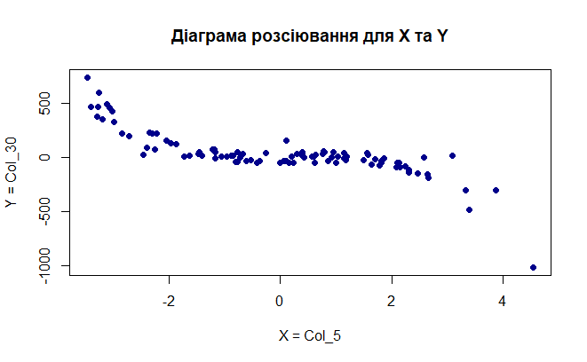

```r
plot(X, Y,
     main = "Діаграма розсіювання для X та Y",
     xlab = "X = Col_5",
     ylab = "Y = Col_30",
     pch  = 19,
     col  = "darkblue")
```

```r
cor_xy <- cor(X, Y)
cor_xy
```

```
[1] -0.7888836
```

Отримане значення коефіцієнта кореляції $r \approx$ -0.7888836.  
Якщо $r > 0$, то між змінними спостерігається прямий лінійний зв’язок: зі збільшенням $X$ значення $Y$ в середньому також зростає.  
Якщо $|r|$ достатньо близьке до 1, зв’язок вважається сильним; якщо ж $|r|$ близьке до 0, лінійний зв’язок слабкий.

### Побудова моделі парної лінійної регресії

Модель парної лінійної регресії описує залежність середнього значення $Y$ від змінної $X$ у вигляді рівняння:
$$\hat{Y} = b_0 + b_1 X,$$
де $b_0$ – вільний член (перетин із віссю $Y$),
$b_1$ – коефіцієнт нахилу, що показує зміну $Y$ при збільшенні $X$ на одну одиницю.

```r
model <- lm(Y ~ X)

summary(model)
```

```
Call:
lm(formula = Y ~ X)

Residuals:
    Min      1Q  Median      3Q     Max
-656.97  -73.52    7.46   68.76  409.47

Coefficients:
            Estimate Std. Error t value Pr(>|t|)
(Intercept)   31.999     12.781   2.504   0.0139 *
X            -85.676      6.742 -12.708   <2e-16 ***
---
Signif. codes:  0 ‘***’ 0.001 ‘**’ 0.01 ‘*’ 0.05 ‘.’ 0.1 ‘ ’ 1

Residual standard error: 127.8 on 98 degrees of freedom
Multiple R-squared:  0.6223,    Adjusted R-squared:  0.6185
F-statistic: 161.5 on 1 and 98 DF,  p-value: < 2.2e-16
```

Коефіцієнт $b_1$ інтерпретується так: при збільшенні $X$ на 1 одиницю, середнє значення $Y$ змінюється приблизно на $b_1^\*$ одиниць.

### Графік з лінією регресії

Для наочного відображення моделі накладемо пряму регресії на діаграму розсіювання.  
Це дозволить порівняти реальні спостереження з теоретичними значеннями, що прогнозуються моделлю.

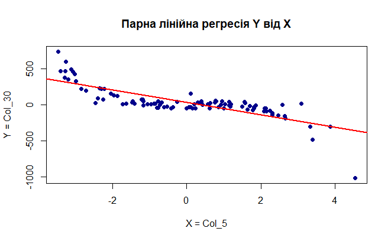

```r
plot(X, Y,
     main = "Парна лінійна регресія Y від X",
     xlab = "X = Col_5",
     ylab = "Y = Col_30",
     pch  = 19,
     col  = "darkblue")

abline(model, col = "red", lwd = 2)
```

### Оцінка якості моделі (R², значущість)

У виводі `summary(model)` наведено також: - коефіцієнт детермінації $R^2$, який показує частку варіації $Y$, пояснену побудованою лінійною моделлю; - значення p-value для коефіцієнта $b_1$.

Якщо $R^2$ достатньо велике, а p-value для $b_1$ менше за обраний рівень значущості (наприклад, $\alpha = 0{,}05$), то можна зробити висновок, що модель є статистично значущою, а змінна $X$ істотно впливає на $Y$.

### Висновки

За діаграмою розсіювання та коефіцієнтом кореляції встановлено наявність досить сильного оберненого лінійного розв’язку.

За методом найменших квадратів побудовано модель парної лінійної регресії
$$\hat{Y} = b_0^\* + b_1^\* X,$$
параметри якої є статистично значущими (за результатами перевірки p-value).
Значення коефіцієнта детермінації $R^2 \approx$ 0.62 свідчить про те, що модель пояснює приблизно 62% варіації результативної змінної $Y$.

Отже, побудована лінійна модель може бути використана для приблизного прогнозування значень $Y$ за відомими значеннями $X$ у межах досліджуваного діапазону даних.